# 2025 Women’s Track Running: Fixing Non-Linear Data with a Log Transformations | SOLUTIONS

```r
library(tidyverse)
library(ggplot2)

track <- read.csv("WomensTrack2025.csv")
```

### 1. Define a model using distance (Event) to predict speed and interpret the R-squared for the model.

```r
mod_track <- lm(Speed ~ Event, track)
summary(mod_track)
```

```
Call:
lm(formula = Speed ~ Event, data = track)

Residuals:
     Min       1Q   Median       3Q      Max
-1.35805 -0.88282  0.03831  0.99845  1.46487

Coefficients:
              Estimate Std. Error t value Pr(>|t|)
(Intercept)  7.709e+00  6.225e-02  123.84   <2e-16 ***
Event       -3.317e-04  1.457e-05  -22.76   <2e-16 ***
---
Signif. codes:  0 '***' 0.001 '**' 0.01 '*' 0.05 '.' 0.1 ' ' 1

Residual standard error: 0.9327 on 349 degrees of freedom
Multiple R-squared:  0.5976,    Adjusted R-squared:  0.5964
F-statistic: 518.2 on 1 and 349 DF,  p-value: < 2.2e-16
```

The adjusted R-squared of this model is 0.596. This means that 59.6% of the variation of Speed can be explained by a linear model using event distance as a predictor.

### 2. Make a scatterplot representing the model you defined.

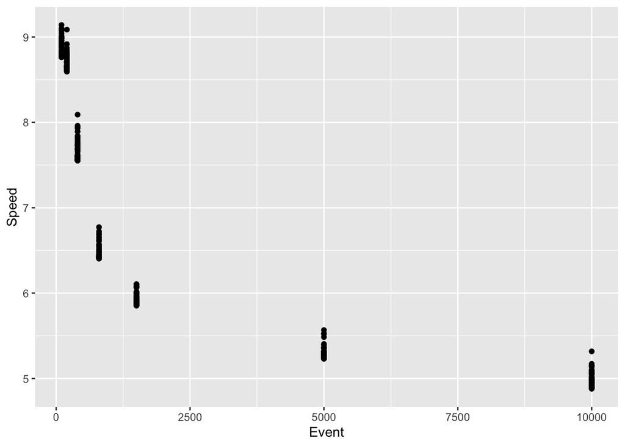

```r
ggplot(track, aes(x = Event, y = Speed)) +
  geom_point()
```

#### 2.1. What do you notice? (think of model conditions)

The data does not match a linear trend. There is clear curvature in the data. Speed seems to at first, dramatically decrease as distance increases, but the speed at which it decreases slows as distance continues to grow.

#### 2.2. Given the context from the first paragraph and/or your background knowledge of the sport, give a possible explanation for what you noticed.

Answers may vary. Students may point to the fact that distance runners have to run for longer, and therefore cannot most likely maintain their fastest possible speed for this time period. The sprinters, on the other hand, must do exactly that, as they only have a short period of time to get and keep the lead.

### 3. Based on the model’s issue, apply a transformation to the data to make a linear model more appropriate.

```r
track <- track |> mutate(ln_distance = log(Event))
```

### 4. Make a scatterplot showing the transformed relationship.

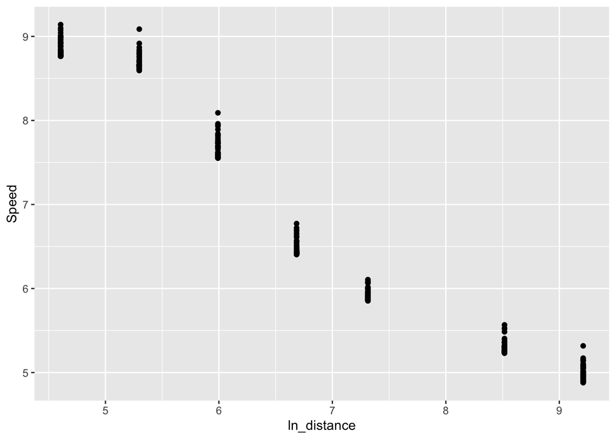

```r
ggplot(track, aes(x = ln_distance, y = Speed)) +
  geom_point()
```

### 5. Define a model using the transformed data and print a summary.

```r
transformation_track <- lm(Speed ~ ln_distance, track)
summary(transformation_track)
```

```
Call:
lm(formula = Speed ~ ln_distance, data = track)

Residuals:
     Min       1Q   Median       3Q      Max
-0.55817 -0.33019 -0.00245  0.31186  0.84663

Coefficients:
            Estimate Std. Error t value Pr(>|t|)
(Intercept) 13.12022    0.08295  158.18   <2e-16 ***
ln_distance -0.92106    0.01190  -77.42   <2e-16 ***
---
Signif. codes:  0 '***' 0.001 '**' 0.01 '*' 0.05 '.' 0.1 ' ' 1

Residual standard error: 0.3448 on 349 degrees of freedom
Multiple R-squared:  0.945, Adjusted R-squared:  0.9448
F-statistic:  5995 on 1 and 349 DF,  p-value: < 2.2e-16
```

### 6. Interpret the R-squared for this model and compare it to the R-squared from question 1.

The adjusted R-squared for this model is 0.945. This means that 94.5% of the variation in speed can be explained by a linear model using the natural log of distance as a predictor. This is significantly higher than the R-squared for the model without the transformation, making the transformed model more useful for predicting speed based on event distance.

Look back at your scatterplots and notice that despite the increased appropriateness of the transformed model, the data still has some curvature. To deal with this stubborn curvature we will apply another transformation.

### 7. Apply an appropriate transformation to the Speed variable in the data.

```r
track <- track |> mutate(ln_speed = log(Speed))
```

### 8. Make a scatterplot showing this relationship.

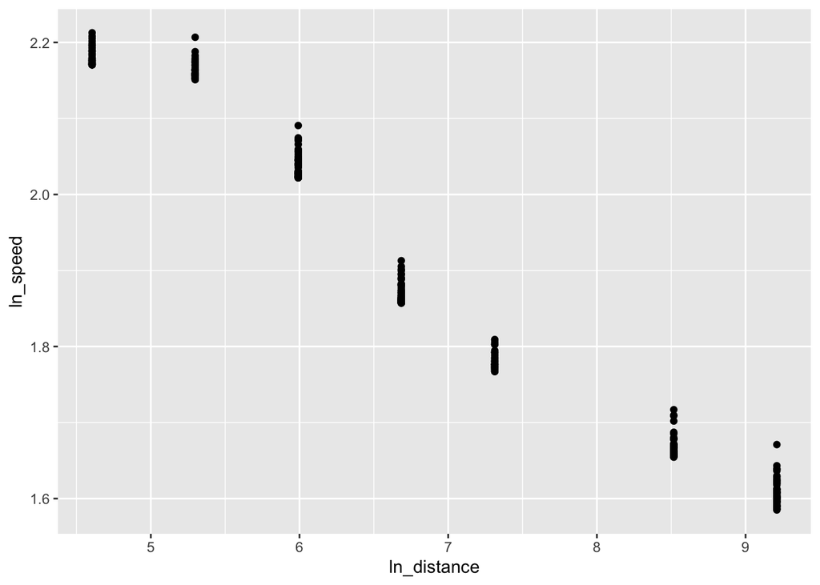

```r
ggplot(track, aes(x = ln_distance, y = ln_speed)) +
  geom_point()
```

### 9. Define a model using the transformed data and print a summary.

```r
transformation2_track <- lm(ln_speed ~ ln_distance, track)
summary(transformation2_track)
```

```
Call:
lm(formula = ln_speed ~ ln_distance, data = track)

Residuals:
      Min        1Q    Median        3Q       Max
-0.065206 -0.030988 -0.000751  0.034072  0.099712

Coefficients:
             Estimate Std. Error t value Pr(>|t|)
(Intercept)  2.829909   0.009810  288.49   <2e-16 ***
ln_distance -0.136421   0.001407  -96.97   <2e-16 ***
---
Signif. codes:  0 '***' 0.001 '**' 0.01 '*' 0.05 '.' 0.1 ' ' 1

Residual standard error: 0.04078 on 349 degrees of freedom
Multiple R-squared:  0.9642,    Adjusted R-squared:  0.9641
F-statistic:  9402 on 1 and 349 DF,  p-value: < 2.2e-16
```

### 10. Which of the three models you defined do you prefer?

```r
AIC(transformation_track)
```

```
[1] 252.7047
```

```r
AIC(transformation2_track)
```

```
[1] -1245.948
```

```r
BIC(transformation_track)
```

```
[1] 264.2871
```

```r
BIC(transformation2_track)
```

```
[1] -1234.365
```

Answers may vary. Based on the R-squared, the models explain similar amounts of the variation in the data. The double log transformed model explains slightly more, and if you look at the AIC and BIC of the models, these measurements support that. The AIC and BIC for the double log transformed model are significantly lower. Because of these measures, I prefer the double log transformed model.

### 11. Is there a downside to the model you prefer?

Answers will vary. For the double log model: interpretations are more difficult. For the single transformation model: there is still some curvature that makes the model less appropriate.